# Validación EPSOC

Equipo EPSOC

22 March, 2019

# 1 Introducción

Este documento consiste en una revisión del proceso de validación de EPSOC 2018. Se trata de un documento reproducible y dinámico que será actualizado cada vez que haya una nueva entrega de datos durante el trabajo de campo. El código está inserto dentro del documento, pero replegado. Para verlo hacer click en cuadro `code`.

# 2 Preámbulo

Se cargan los datos en el formato entregado y se homogeneiza el formato en minúscula y usando puntos (“`.`”) para separar en vez de guiones bajos (“`_`”).

```r
pacman::p_load(tidyverse, lubridate, anytime, chron,
               haven, sf,
               sjlabelled, sjmisc,
               validate, eeptools, kableExtra, janitor, here, naniar,
               captioner)

if(Sys.info()[["user"]] == 'caayala'){
  path <- "/Users/caayala/Dropbox (DESUC)/DESUC/Proyectos/3 Políticas Públicas/EPSOC 2018/BD/"
} else if(Sys.info()[["user"]] == 'Andres') {
  path <- "/Users/Andres/Dropbox (DESUC)/Proyectos/3 Políticas Públicas/EPSOC 2018/BD/"
} else if(Sys.info()[["user"]] == 'CM') {
  path <- "C:/Users/CM/Dropbox/2016 - Mecanismos de legitimación de la desigualdad/EPSOC/datos/"
}

data_files <- list.files(path)
data_files <- data_files[grep("^[0-9]{6}", data_files)]
newest <- gsub(" .*$", "", data_files)
newest <- lubridate::ymd(newest)
newest <- data_files[which(newest == max(newest))]

epsoc <-haven::read_spss(paste0(path, newest)) %>%
  clean_names() %>%
  mutate(region = folio %/% 100000,
         i_1_orden = as.integer(i_1_orden))

names(epsoc) <- tolower(gsub("_", ".", names(epsoc)))

grabacion <- FALSE
```

```r
kable_estilo <- function(tabla){
  tabla %>%
    kableExtra::kable_styling(bootstrap_options = c("striped", "hover", "condensed"),
                              full_width=F)
}
```

```r
makeVlist <- function(dta) {
        labels <- sapply(dta, function(x) attr(x, "label"))
        tibble(name = names(labels),
               label = labels)

}  ## Etiquetas variables
labs.epsoc <- makeVlist(epsoc)
labs.epsoc <- labs.epsoc %>%
  mutate(label2 = map_chr(label, toString))

labs.epsoc <- get_label(epsoc)
```

# 3 General

La actual base cuenta con 1238 casos recogidos entre el 2018-10-17 y el 2019-03-14.

```r
epsoc %>%
  count(region, status) %>%
  spread(status, n) %>%
  janitor::adorn_totals(where = c('row', 'col')) %>%
  kable() %>%
  kable_estilo()
```

| region | Aceptado | Aceptado con reparos | Requires Approval | Total |
| --- | --- | --- | --- | --- |
| 2 | 303 | 57 | NA | 360 |
| 9 | 105 | 190 | 13 | 308 |
| 13 | 419 | 147 | 4 | 570 |
| Total | 827 | 394 | 17 | 1238 |

## 3.1 Distribución encuestado

```r
epsoc <- epsoc %>%
  mutate(rango_edad = rec(edad.seleccionado,
                          rec = "1:17 =  1[menor de 18 años];
                                 18:24 = 2[18 a 24 años];
                                 25:44 = 3[25 a 44 años];
                                 45:59 = 4[45 a 59 años]"))

frq(epsoc, rango_edad)
```

```
##
## # rango_edad <numeric>
## # total N=1238  valid N=1237  mean=3.25  sd=0.70
##
##  val            label frq raw.prc valid.prc cum.prc
##    1 menor de 18 años   0    0.00      0.00    0.00
##    2     18 a 24 años 191   15.43     15.44   15.44
##    3     25 a 44 años 548   44.26     44.30   59.74
##    4     45 a 59 años 498   40.23     40.26  100.00
##   NA               NA   1    0.08        NA      NA
```

```r
epsoc %>%
  filter(is.na(rango_edad)) %>%
  select(sexo.seleccionado, edad.seleccionado, situacion.laboral.seleccionado)
```

```
## # A tibble: 1 x 3
##   sexo.seleccionado edad.seleccionado situacion.laboral.seleccionado
##   <dbl+lbl>                     <dbl> <dbl+lbl>
## 1 1                                60 1
```

Probablemente discrepancia de edad para las personas mayores de 59 años se debe a una confusión entre edad reportada o fecha de cumpleaños. Quedarán asignados al grupo de edad `rango_edad == 4`.

```r
epsoc <- epsoc %>%
  mutate(rango_edad = replace(rango_edad, edad.seleccionado %in% c(60, 61), 4))

epsoc %>%
  count(sexo.seleccionado, rango_edad, situacion.laboral.seleccionado) %>%
  mutate_all(as_label) %>%
  mutate(prop = round(n/sum(n), 4)) %>%
  kable() %>%
  kable_estilo()
```

| sexo.seleccionado | rango_edad | situacion.laboral.seleccionado | n | prop |
| --- | --- | --- | --- | --- |
| Hombre | 18 a 24 años | Trabaja | 43 | 0.0347 |
| Hombre | 18 a 24 años | No trabaja | 46 | 0.0372 |
| Hombre | 25 a 44 años | Trabaja | 177 | 0.1430 |
| Hombre | 25 a 44 años | No trabaja | 17 | 0.0137 |
| Hombre | 45 a 59 años | Trabaja | 138 | 0.1115 |
| Hombre | 45 a 59 años | No trabaja | 24 | 0.0194 |
| Mujer | 18 a 24 años | Trabaja | 32 | 0.0258 |
| Mujer | 18 a 24 años | No trabaja | 70 | 0.0565 |
| Mujer | 25 a 44 años | Trabaja | 228 | 0.1842 |
| Mujer | 25 a 44 años | No trabaja | 126 | 0.1018 |
| Mujer | 45 a 59 años | Trabaja | 190 | 0.1535 |
| Mujer | 45 a 59 años | No trabaja | 147 | 0.1187 |

## 3.2 Duración entrevistas

La distribución de la duración de las entrevistas registrada por las tablets se puede ver en la siguiente figura.

```r
homologar_fechas <- function(fecha){
  fecha %>%
    str_replace_all(c("^\\D{3} " = "", '(.*)(\\d{4}$)' = '\\2 \\1')) %>%
    anytime::anytime()
}

epsoc <- epsoc %>%
  mutate_at(vars(starts_with('time')), homologar_fechas)
```

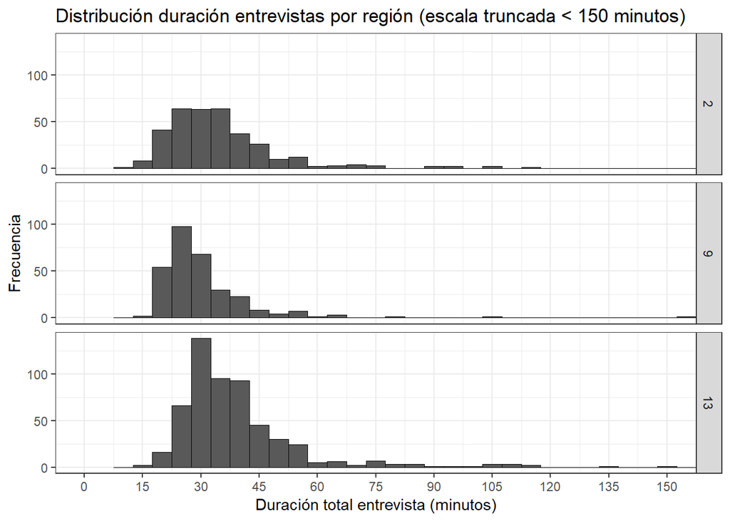

```r
epsoc <- epsoc %>%
  mutate(duration = str_replace_all(duration, c('-' = '', '^(\\d{2})' = '0\\.\\1'))) %>%
  separate(duration, into = c('dura.d', 'duracion'), sep = '\\.', convert = TRUE, remove = FALSE) %>%
  mutate(duracion.t = as.duration(hms(duracion) + hms(hms::hms(hour = (24 * dura.d)))))

epsoc$duracion.t.min <- epsoc$duracion.t@.Data/60

epsoc %>%
  ggplot(aes(x = duracion.t.min)) +
  geom_histogram(binwidth = 5) +
  theme_bw() +
  ggtitle("Distribución duración entrevistas por región (escala truncada < 150 minutos)") +
  labs(x = "Duración total entrevista (minutos)",
       y = "Frecuencia") +
  coord_cartesian(xlim = 0:150) +
  scale_x_continuous(breaks = seq(0, 150, by = 15)) +
  facet_grid(as_factor(region) ~ .)
```

```r
epsoc %>%
  filter(as.double(duracion.t.min) < 20) %>%
  select(folio, duracion.t.min) %>%
  knitr::kable(col.names = c("Folio", "Duración (minutos)"),
               caption = "Entrevistas de menos de 20 minutos",
               digits = 1) %>%
  kable_estilo() %>%
  column_spec(1, width = "10em") %>%
  column_spec(2, width = "10em")
```

Entrevistas de menos de 20 minutos

| Folio | Duración (minutos) |
| --- | --- |
| 200329 | 19.8 |
| 201186 | 18.2 |
| 201293 | 19.7 |
| 201350 | 11.4 |
| 201434 | 19.9 |
| 201863 | 16.0 |
| 201921 | 16.4 |
| 201947 | 19.1 |
| 202382 | 19.4 |
| 202465 | 19.6 |
| 202879 | 16.4 |
| 202895 | 19.3 |
| 203190 | 18.7 |
| 203372 | 18.4 |
| 203836 | 17.9 |
| 204065 | 19.0 |
| 204396 | 19.5 |
| 204867 | 16.4 |
| 204966 | 18.6 |
| 205039 | 17.2 |
| 205443 | 19.4 |
| 205484 | 16.6 |
| 207431 | 16.9 |
| 207456 | 19.4 |
| 207464 | 14.2 |
| 207969 | 19.1 |
| 208017 | 18.5 |
| 208462 | 19.8 |
| 901025 | 20.0 |
| 901850 | 17.2 |
| 902296 | 17.6 |
| 902312 | 19.2 |
| 902940 | 17.9 |
| 903013 | 19.3 |
| 903088 | 20.0 |
| 903336 | 19.9 |
| 903393 | 18.1 |
| 903476 | 18.2 |
| 903518 | 19.6 |
| 903575 | 19.2 |
| 903971 | 19.3 |
| 904425 | 19.5 |
| 904755 | 17.4 |
| 905224 | 18.2 |
| 905240 | 17.6 |
| 905273 | 18.4 |
| 1301191 | 19.2 |
| 1305671 | 17.4 |
| 1305697 | 18.4 |
| 1306489 | 19.7 |
| 1309111 | 19.4 |
| 1310127 | 12.8 |
| 1310135 | 19.6 |

```r
epsoc %>%
  filter(as.double(duracion.t.min) > 150) %>%
  transmute(folio, duracion.t.min / 60) %>%
  knitr::kable(col.names = c("Folio", "Duración (horas)"),
               caption = "Entrevistas de más de 150 minutos",
               digits = 1) %>%
  kable_estilo() %>%
  column_spec(1, width = "10em") %>%
  column_spec(2, width = "10em")
```

Entrevistas de más de 150 minutos

| Folio | Duración (horas) |
| --- | --- |
| 200444 | 72.8 |
| 200527 | 69.8 |
| 200550 | 4.6 |
| 200717 | 49.6 |
| 202135 | 71.9 |
| 202671 | 25.7 |
| 203349 | 3.4 |
| 900183 | 2.6 |
| 902569 | 2.7 |
| 903443 | 235.0 |
| 903815 | 236.7 |
| 903922 | 91.3 |
| 903963 | 120.9 |
| 905976 | 14.3 |
| 1301928 | 18.6 |
| 1301951 | 192.9 |
| 1302157 | 4.2 |
| 1302421 | 96.4 |
| 1303254 | 25.1 |
| 1303262 | 25.6 |
| 1303643 | 24.6 |
| 1303833 | 4.0 |
| 1303999 | 6.9 |
| 1304062 | 23.6 |
| 1304732 | 24.4 |
| 1305465 | 23.4 |
| 1305515 | 72.0 |
| 1306646 | 2.8 |
| 1306877 | 44.6 |
| 1307214 | 2.5 |
| 1307339 | 218.9 |
| 1307370 | 50.1 |
| 1310192 | 13.7 |
| 1310515 | 22.6 |
| 1311471 | 5.2 |
| 1312958 | 50.4 |

## 3.3 Producción por día

Cantidad de encuestas realizadas por día.

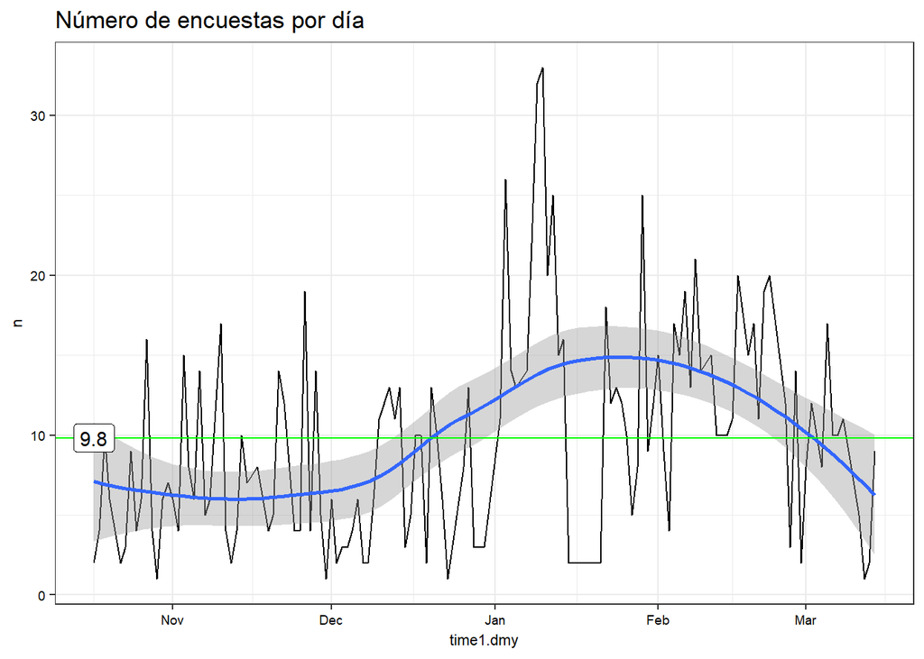

```r
## Comienzo encuesta
epsoc$time1.hms <- hms::as.hms(epsoc$time1)
epsoc$time1.wday <- lubridate::wday(epsoc$time1)
epsoc$time1.dmy <- date(epsoc$time1)

epsoc %>%
  count(time1.dmy) %>%
  mutate(n_mean = mean(n)) %>%
  ggplot(aes(x = time1.dmy, y = n)) +
  geom_line() +
  geom_smooth() +
  geom_hline(aes(yintercept = n_mean), colour = 'green') +
  geom_label(aes(x = min(time1.dmy)[[1]], y = n_mean[[1]], label = round(n_mean, 1))) +
  labs(title = 'Número de encuestas por día') #+
```

```r
#  scale_x_date(breaks = '2 weeks')
```

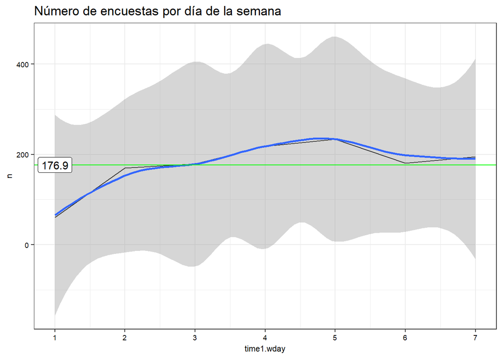

```r
epsoc %>%
  count(time1.wday) %>%
  mutate(n_mean = mean(n)) %>%
  ggplot(aes(x = time1.wday, y = n)) +
  geom_line() +
  geom_smooth() +
  geom_hline(aes(yintercept = n_mean), colour = 'green') +
  geom_label(aes(x = min(time1.wday)[[1]], y = n_mean[[1]], label = round(n_mean, 1))) +
  labs(title = 'Número de encuestas por día de la semana') +
  scale_x_continuous(breaks = seq(7))
```

## 3.4 Georeferrenciación

Existen 350 entrevistas sin datos de georreferenciación:

```r
epsoc %>%
  select(folio, latitude, srvyr) %>%
  group_by(srvyr) %>%
  mutate(n.enc = length(folio)) %>%
  filter(is.na(latitude)) %>%
  select(folio, srvyr, n.enc) %>%
  mutate(n.enc.sg = (length(folio)/n.enc)*100) %>%
  arrange(srvyr, folio) %>%
  group_by_at(vars(-folio)) %>%
  nest() %>%
  mutate(Folio = map_chr(data, ~ flatten(.) %>% str_c(., collapse = ', '))) %>%
  select(-data) %>%
  kable(digits = 1,
        col.names = c("Encuestador", "Total encuestas", "% sin georef.", "folios")) %>%
  kable_estilo()
```

| Encuestador | Total encuestas | % sin georef. | folios |
| --- | --- | --- | --- |
| ageraldo.2 | 66 | 42.4 | 200857, 201376, 201475, 201715, 201939, 202143, 202465, 202598, 202770, 203034, 203042, 203083, 203216, 203224, 203240, 203315, 203331, 203570, 203877, 203885, 204040, 204081, 204289, 204297, 204719, … |
| atoledo.9 | 227 | 3.1 | 901561, 903823, 903849, 904144, 904177, 904524, 906164 |
| cobando.9 | 26 | 23.1 | 903344, 903443, 903450, 903625, 903658, 906438 |
| i.perez | 24 | 33.3 | 1300433, 1301514, 1301530, 1302850, 1312610, 1312636, 1312644, 1312669 |
| j.morales | 11 | 9.1 | 1305465 |
| jossio.2 | 100 | 50.0 | 200253, 200493, 200691, 201038, 201053, 201061, 201186, 201293, 201392, 201491, 201590, 201749, 201863, 202192, 202226, 202242, 202267, 202382, 202481, 202796, 202879, 202895, 203059, 203067, 203075, … |
| ksakuda.2 | 35 | 51.4 | 201483, 201921, 202473, 202788, 203323, 203372, 203380, 204016, 207415, 207423, 207431, 207449, 207456, 207464, 208017, 208033, 208041, 208058 |
| l.mancilla | 21 | 100.0 | 901520, 901546, 901553, 901579, 901595, 903112, 903120, 903138, 903146, 903153, 903161, 903179, 903187, 903195, 904342, 904367, 904375, 904383, 904391, 905257, 905281 |
| M.Alert | 5 | 100.0 | 1305234, 1305242, 1306646, 1310515, 1311471 |
| m.calderon | 2 | 100.0 | 1310226, 1311935 |
| mdiaz.2 | 85 | 7.1 | 202697, 203117, 203257, 203265, 203273, 205229 |
| mrobles.2 | 58 | 51.7 | 200212, 200477, 201111, 201772, 202218, 202234, 202275, 202572, 204339, 204818, 204875, 205013, 205047, 205450, 205468, 205666, 205690, 205864, 205948, 205963, 206110, 206151, 206318, 206623, 206631, … |
| ncaceres.2 | 1 | 100.0 | 205930 |
| nicol.alarcon | 6 | 100.0 | 1310127, 1310135, 1310150, 1310168, 1310176, 1310192 |
| p.aguilera | 4 | 75.0 | 1300912, 1300953, 1303726 |
| p.gajardo | 7 | 42.9 | 1302934, 1303510, 1303528 |
| p.vegazo | 150 | 6.7 | 1300870, 1303825, 1304542, 1309111, 1309129, 1309137, 1309160, 1309178, 1311331, 1311364 |
| rfigueroa.9 | 8 | 100.0 | 901918, 901926, 902023, 902056, 902072, 905919, 905943, 905950 |
| s.gonzalez | 16 | 75.0 | 1301910, 1301928, 1301936, 1301944, 1301951, 1301969, 1302066, 1303916, 1303940, 1303965, 1305911, 1307057 |
| v.becerra | 2 | 100.0 | 1300672, 1300698 |
| v.espinoza | 103 | 2.9 | 1304575, 1310572, 1310580 |
| v.sierra | 171 | 69.0 | 1300151, 1300169, 1300177, 1300185, 1300193, 1300250, 1300268, 1300276, 1300284, 1300292, 1300474, 1300482, 1300490, 1300557, 1300565, 1300573, 1300581, 1300599, 1300789, 1300797, 1301373, 1301381, 13… |
| ycifuente.9 | 4 | 50.0 | 901314, 901322 |

## 3.5 Puntos de encuestas

```r
epsoc_geo <- epsoc %>%
  select(folio, sbj.num, region, srvyr, longitude, latitude) %>%
  filter(!is.na(latitude)) %>%
  sf::st_as_sf(coords = c('longitude', 'latitude'),
               crs = "+proj=longlat +ellps=GRS80")

sf::write_sf(epsoc_geo,
             here::here('validacion_epsoc_puntos_respuesta.kml'),
             dataset_options=c("NameField=folio"),
             delete_dsn=TRUE)
```

### 3.5.1 Antofagasta

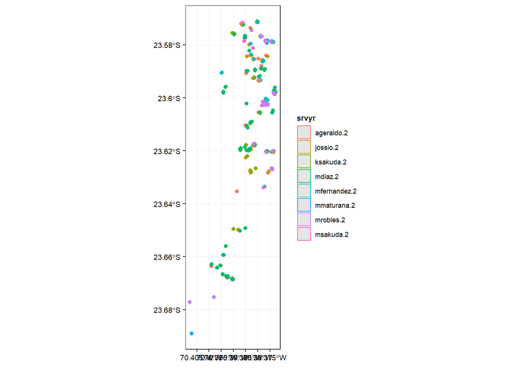

```r
epsoc_geo %>%
  filter(region == 2) %>%
  ggplot(aes(color = srvyr)) +
  geom_sf()
```

### 3.5.2 Temuco

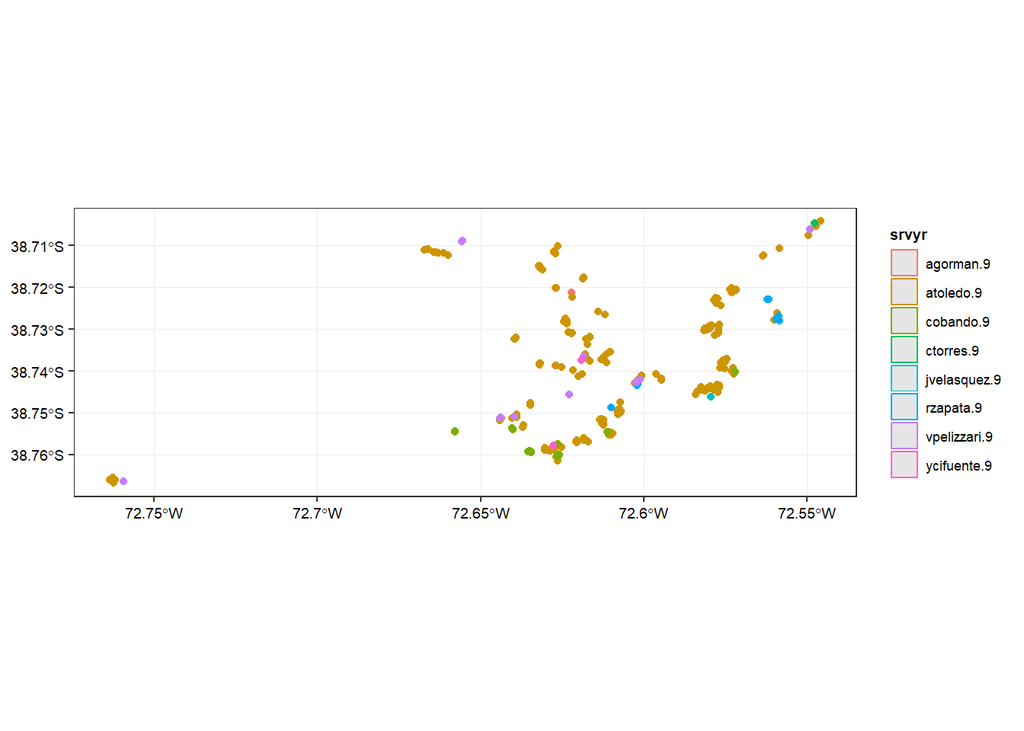

```r
epsoc_geo %>%
  filter(region == 9) %>%
  ggplot(aes(color = srvyr)) +
  geom_sf()
```

### 3.5.3 Santiago

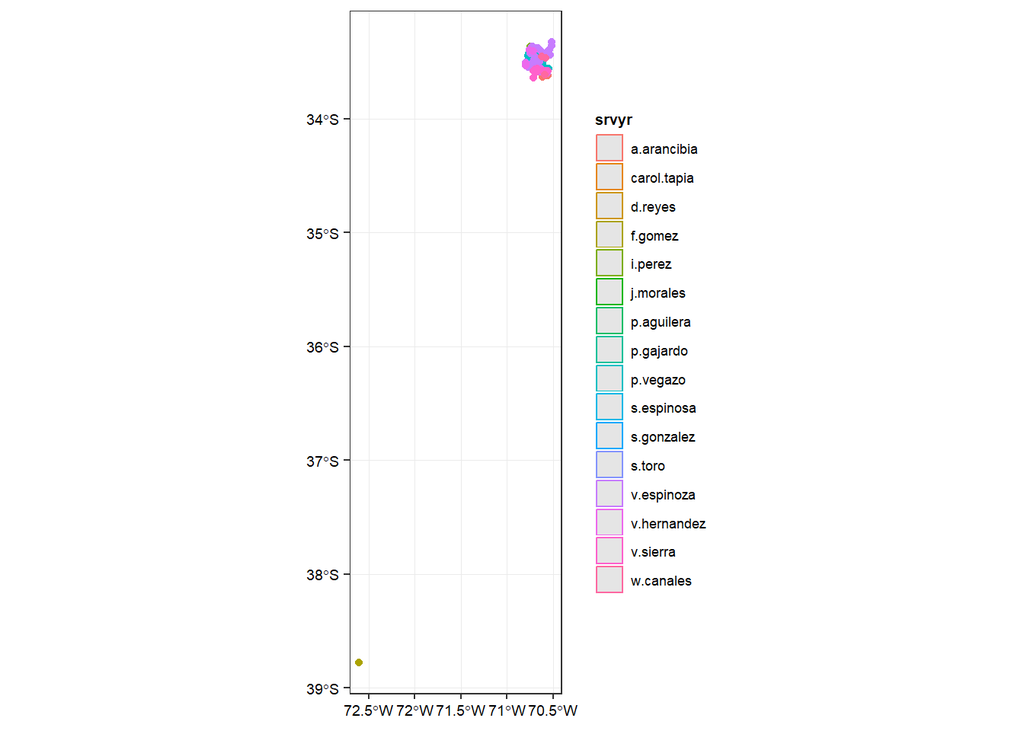

```r
epsoc_geo %>%
  filter(region == 13) %>%
  ggplot(aes(color = srvyr)) +
  geom_sf()
```

# 4 Experimentos

EPSOC contiene dos experimentos que constituyen un foco de análisis del instrumento. El primer experimento consiste en un diseño factorial a través viñetas. El segundo se trata de una aleatorización del orden de preguntas sobre recompensa percibida y justa para tres objetos de evaluación: un obrero, un presidente de empresa y el respondente. Actualmente no es posible validar estos experimento por falta de información.

## 4.1 Viñetas

Para validar el proceso con las viñetas necesitamos:

- Una breve explicación de cómo está codificado el experimento de las viñetas en la base de datos
- La base de datos que asocia los folios con sets de viñeta en orden presentado
- Acceso a grabaciones de voz durante el proceso de entrevista para asegurarnos que están bien asociadas las escalas con las variables

### 4.1.1 Distribución de viñetas

Revisar la distribución efectiva captada de los decks de viñetas en terreno hasta el momento.

```r
epsoc %>%
  select(folio, i.1.grupo) %>%
  head()
```

```
## # A tibble: 6 x 2
##    folio i.1.grupo
##    <dbl> <chr>
## 1 200139 23
## 2 200147 17
## 3 200162 11
## 4 200212 15
## 5 200220 15
## 6 200238 31
```

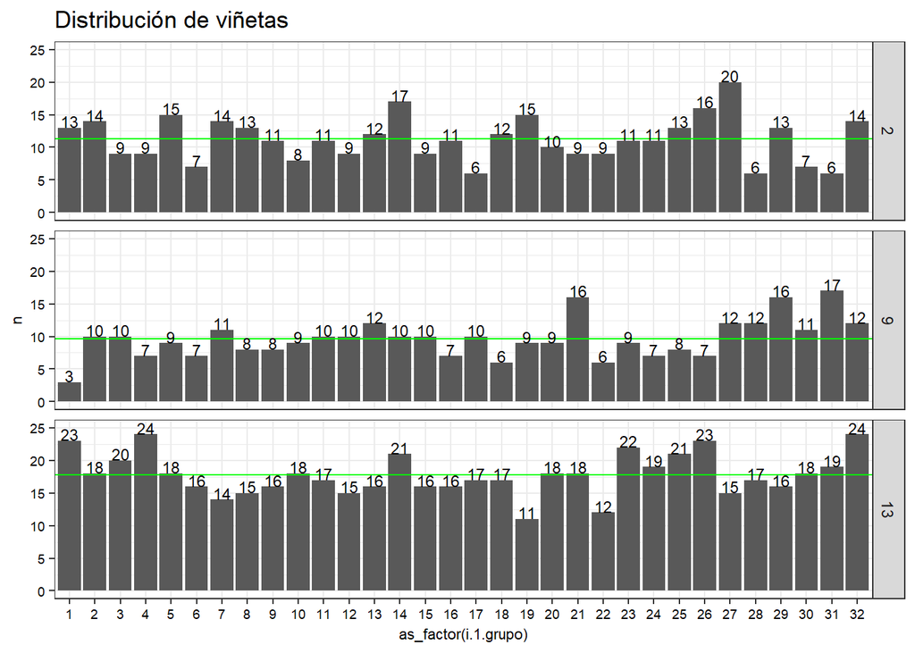

```r
epsoc %>%
  transmute(i.1.grupo = as.integer(i.1.grupo),
            region) %>%
  group_by_all() %>%
  count() %>%
  group_by(region) %>%
  mutate(n_mean = mean(n)) %>%
  ggplot(aes(x = as_factor(i.1.grupo), y = n)) +
  geom_col() +
  geom_hline(aes(group = region, yintercept = n_mean), colour = 'green') +
  geom_text(aes(label = ..y..), nudge_y = 1, size = 3) +
  facet_grid(rows = vars(region)) +
  labs(title = 'Distribución de viñetas')
```

### 4.1.2 Duración ejercicio

- Los marcadores de tiempo `time2` y `time3` no siguen un formato homogéneo para registrar la hora. Por ejemplo, en algún caso se utiliza el formato “2018-10-27T19:05:08-03:00” y en otros “Fri Oct 19 13:01:59 -0300 2018”
- Homogeneizar formatos de tiempos y fechas a ISO8601

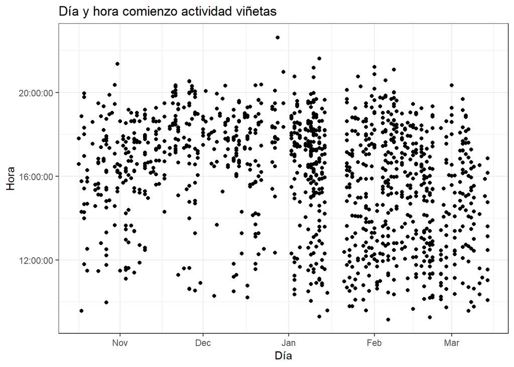

```r
## Comienzo viñetas
epsoc$time2.hms <- hms::as.hms(epsoc$time2)
epsoc$time2.dmy <- date(epsoc$time2)

## Fin viñetas
epsoc$time3.hms <- hms::as.hms(epsoc$time3)
epsoc$time3.dmy <- date(epsoc$time3)

epsoc$dura.vinetas <- difftime(epsoc$time3, epsoc$time2,
                               units = "mins")

ggplot(epsoc, aes(x = time2.dmy, y = time2.hms)) +
  geom_point() +
  labs(x = "Día", y = "Hora") +
  ggtitle("Día y hora comienzo actividad viñetas") +
  theme_bw()
```

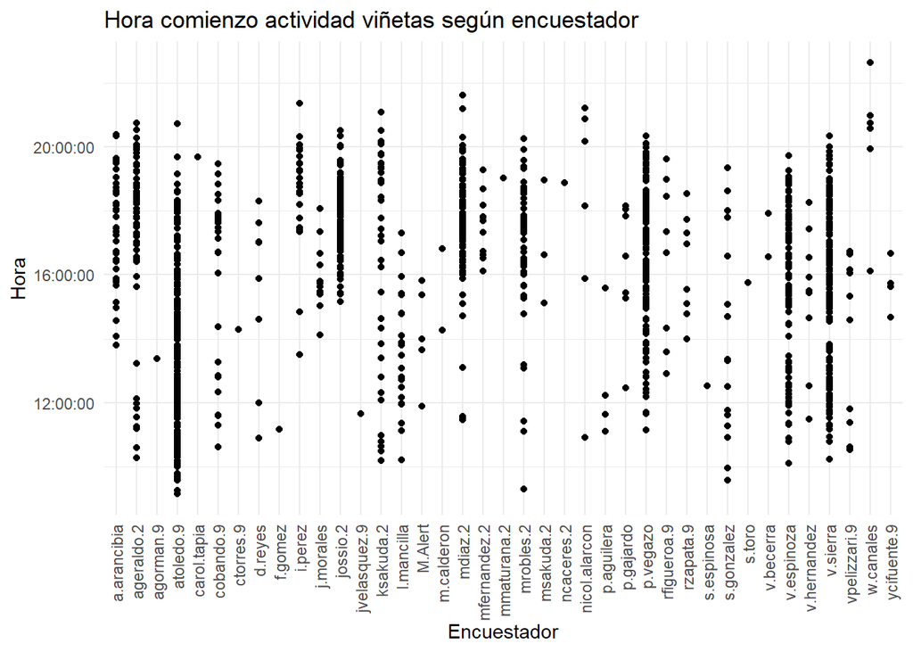

```r
ggplot(epsoc, aes(x = srvyr, y = time2.hms)) +
  geom_point() +
  labs(x = "Encuestador", y = "Hora") +
  ggtitle("Hora comienzo actividad viñetas según encuestador") +
  theme_minimal() +
  theme(axis.text.x = element_text(angle = 90, vjust = .5, hjust = 1))
```

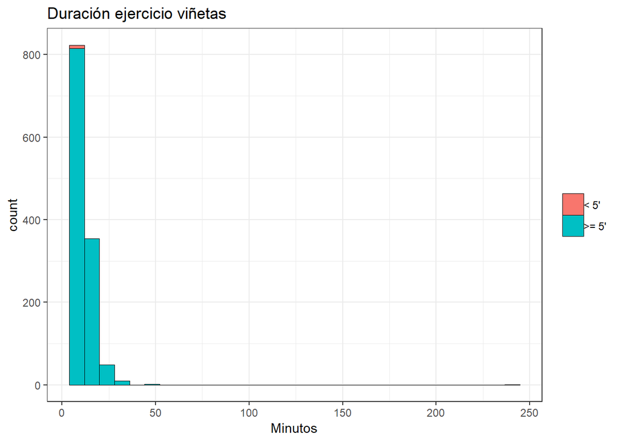

```r
epsoc %>%
  mutate(vin.cort = ifelse(dura.vinetas < 5, "< 5'", ">= 5'")) %>%
  ggplot(aes(dura.vinetas)) +
  geom_histogram(aes(fill = vin.cort)) + theme_bw() +
  theme(legend.title=element_blank()) +
  ggtitle("Duración ejercicio viñetas") +
  xlab("Minutos")
```

Como se puede ver en la figura anterior, la distribución del tiempo de duración del ejercicio de viñetas es variable. En términos de validación, llama la atención que se logre realizar el ejercicio en menos de cinco minutos. Estos casos deberían ser revisados apenas sea posible.

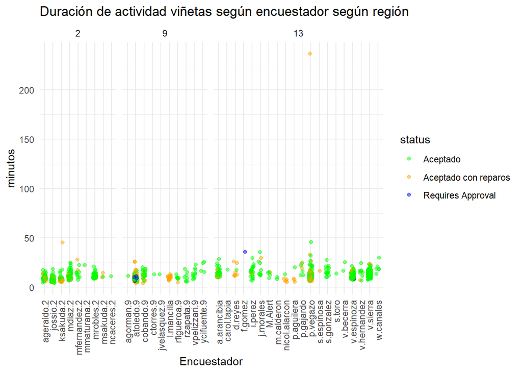

```r
ggplot(epsoc, aes(x = srvyr, y = dura.vinetas,
                  colour = status)) +
  geom_point(alpha = 0.5,
             position = position_jitter(width = .2)) +
  scale_color_manual(values = c('green', 'orange', 'blue')) +
  facet_grid(cols = vars(region), scales = 'free_x', space = 'free_x') +
  labs(x = "Encuestador", y = "minutos") +
  ggtitle("Duración de actividad viñetas según encuestador según región") +
  theme_minimal() +
  theme(axis.text.x = element_text(angle = 90, vjust = .5, hjust = 1))
```

En particular, deben supervisarse las siguientes entrevistas donde el ejercicio duró menos de 10 minutos:

```r
kable(epsoc %>%
        group_by(srvyr) %>%
        mutate(n.enc = length(folio)) %>%
        select(folio, dura.vinetas, srvyr, n.enc) %>%
        filter(dura.vinetas <= 10) %>%
        mutate(n.enc.cort = (length(folio)/n.enc)*100) %>%
        arrange(srvyr, dura.vinetas),
      digits = 1,
      col.names = c("Folio", "Duración viñetas", "Encuestador", "Total encuestas", "% cortas"),
      caption = "Ejercicio viñetas de menos de 10 minutos") %>%
  kable_estilo() #%>%
```

Ejercicio viñetas de menos de 10 minutos

| Folio | Duración viñetas | Encuestador | Total encuestas | % cortas |
| --- | --- | --- | --- | --- |
| 1305861 | 9.8 mins | a.arancibia | 42 | 4.8 |
| 1305879 | 9.9 mins | a.arancibia | 42 | 4.8 |
| 202465 | 5.0 mins | ageraldo.2 | 66 | 65.2 |
| 204289 | 5.6 mins | ageraldo.2 | 66 | 65.2 |
| 203711 | 5.9 mins | ageraldo.2 | 66 | 65.2 |
| 205211 | 6.4 mins | ageraldo.2 | 66 | 65.2 |
| 204297 | 6.5 mins | ageraldo.2 | 66 | 65.2 |
| 201129 | 6.9 mins | ageraldo.2 | 66 | 65.2 |
| 200550 | 7.2 mins | ageraldo.2 | 66 | 65.2 |
| 203224 | 7.2 mins | ageraldo.2 | 66 | 65.2 |
| 200543 | 7.5 mins | ageraldo.2 | 66 | 65.2 |
| 204040 | 7.6 mins | ageraldo.2 | 66 | 65.2 |
| 202598 | 7.6 mins | ageraldo.2 | 66 | 65.2 |
| 202648 | 7.7 mins | ageraldo.2 | 66 | 65.2 |
| 203729 | 7.8 mins | ageraldo.2 | 66 | 65.2 |
| 202655 | 7.8 mins | ageraldo.2 | 66 | 65.2 |
| 205237 | 8.0 mins | ageraldo.2 | 66 | 65.2 |
| 204057 | 8.1 mins | ageraldo.2 | 66 | 65.2 |
| 201475 | 8.1 mins | ageraldo.2 | 66 | 65.2 |
| 201376 | 8.1 mins | ageraldo.2 | 66 | 65.2 |
| 203182 | 8.1 mins | ageraldo.2 | 66 | 65.2 |
| 202143 | 8.2 mins | ageraldo.2 | 66 | 65.2 |
| 204131 | 8.2 mins | ageraldo.2 | 66 | 65.2 |
| 203216 | 8.3 mins | ageraldo.2 | 66 | 65.2 |
| 203042 | 8.6 mins | ageraldo.2 | 66 | 65.2 |
| 204727 | 8.6 mins | ageraldo.2 | 66 | 65.2 |
| 203034 | 8.6 mins | ageraldo.2 | 66 | 65.2 |
| 203240 | 8.7 mins | ageraldo.2 | 66 | 65.2 |
| 203877 | 8.8 mins | ageraldo.2 | 66 | 65.2 |
| 200956 | 8.9 mins | ageraldo.2 | 66 | 65.2 |

[output cut: 535 more lines]

```r
#column_spec(1, width = "10em") %>%
#column_spec(2, width = "10em") %>%
#column_spec(3, width = "10em")
```

### 4.1.3 Reconstrucción de variables de outcome

```r
labels_correcion <- function(.vect) {
  replace(.vect, .vect == 6, -1) %>%
    remove_labels(labels = '- 1') %>%
    add_labels(labels = c('- 1' = -1))
}
```

#### 4.1.3.1 Ideología para ego y alter

```r
ideologia_ego <- list(orden1 = c("c0.1", "c1.1.1", "c1.2.1", "c1.3.1", "c1.4.1", "c2.1.1", "c2.2.1", "c2.3.1", "c2.4.1"),
                      orden2 = c("c0.2", "c1.4.2", "c1.1.2", "c1.2.2", "c1.3.2", "c2.4.2", "c2.1.2", "c2.2.2", "c2.3.2"),
                      orden3 = c("c0.3", "c1.3.3", "c1.4.3", "c1.1.3", "c1.2.3", "c2.3.3", "c2.4.3", "c2.1.3", "c2.2.3"),
                      orden4 = c("c0.4", "c1.2.4", "c1.3.4", "c1.4.4", "c1.1.4", "c2.2.4", "c2.3.4", "c2.4.4", "c2.1.4"))

df_ideologia_ego <- epsoc %>%
  select(folio, i.1.orden, !!!flatten_chr(ideologia_ego)) %>%
  nest(-i.1.orden) %>%
  arrange(i.1.orden)

df_ideologia_ego <- df_ideologia_ego %>%
  mutate(orden = ideologia_ego[str_glue("orden{i.1.orden + 1}")],
         data = map2(data, orden, ~select(.x, one_of("folio", .y))),
         data_var = map(data, names) %>% map_chr(str_c, collapse = ', '))

df_ideologia_ego
```

```
## # A tibble: 4 x 4
##   i.1.orden data          orden   data_var
##       <int> <list>        <list>  <chr>
## 1         0 <tibble [296~ <chr [~ folio, c0.1, c1.1.1, c1.2.1, c1.3.1, c1.~
## 2         1 <tibble [324~ <chr [~ folio, c0.2, c1.4.2, c1.1.2, c1.2.2, c1.~
## 3         2 <tibble [319~ <chr [~ folio, c0.3, c1.3.3, c1.4.3, c1.1.3, c1.~
## 4         3 <tibble [299~ <chr [~ folio, c0.4, c1.2.4, c1.3.4, c1.4.4, c1.~
```

```r
map_dfc(df_ideologia_ego$data, get_label) %>%
  mutate_all(str_trunc, width = 25)
```

```
## # A tibble: 10 x 4
##    V1                 V2                V3                V4
##    <chr>              <chr>             <chr>             <chr>
##  1 ""                 ""                ""                ""
##  2 Observe esta esca~ Observe esta esc~ Observe esta esc~ Observe esta esc~
##  3 "Escala \"Las fam~ "Escala \"Las fa~ "Escala \"Las fa~ "Escala \"Las fa~
##  4 "Escala \"Chile n~ "Escala \"Chile ~ "Escala \"Chile ~ "Escala \"Chile ~
##  5 "Escala \"Educaci~ "Escala \"Educac~ "Escala \"Educac~ "Escala \"Educac~
##  6 "Escala \"Más con~ "Escala \"Más co~ "Escala \"Más co~ "Escala \"Más co~
##  7 "Escala \"Las fam~ "Escala \"Las fa~ "Escala \"Las fa~ "Escala \"Las fa~
##  8 "Escala \"Chile n~ "Escala \"Chile ~ "Escala \"Chile ~ "Escala \"Chile ~
##  9 "Escala \"Educaci~ "Escala \"Educac~ "Escala \"Educac~ "Escala \"Educac~
## 10 "Escala \"Más con~ "Escala \"Más co~ "Escala \"Más co~ "Escala \"Más co~
```

```r
suppressWarnings(
  df_ideologia_ego <- df_ideologia_ego %>%
    mutate(data = map(data, ~rename_all(.x, ~c("folio", str_remove(ideologia_ego$orden1,'.\\d{1,2}$'))))) %>%
    select(data) %>%
    unnest()
)

df_ideologia_ego <- copy_labels(df_new = df_ideologia_ego,
                                df_origin = epsoc %>%
                                  select(one_of(c('folio', ideologia_ego$orden1))) %>%
                                  rename_all(~c("folio", str_remove(ideologia_ego$orden1,'.\\d{1,2}$'))))
```

Agregar variables reconstruidas a base de datos.

```r
epsoc <- left_join(epsoc,
                   df_ideologia_ego,
                   by = 'folio')
```

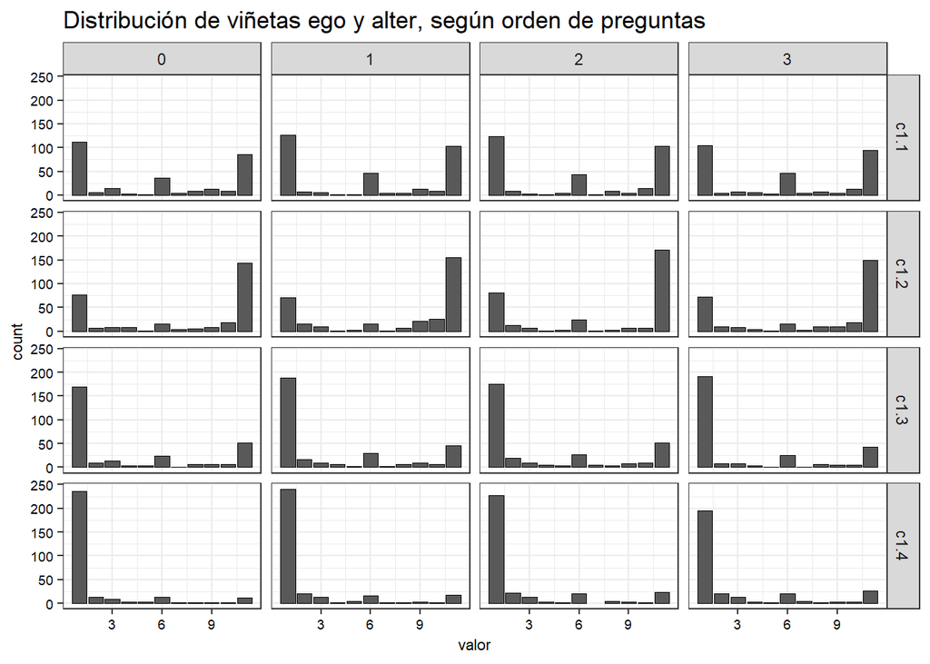

```r
gg_ideologia_orden <- function(.data, var_orden, miss = 88){
  var_orden_quo <- enquo(var_orden)

  .data %>%
    gather('variable', 'valor', -!!var_orden_quo) %>%
    filter(valor < miss) %>%
    ggplot(aes(x = valor)) +
    geom_bar() +
    facet_grid(rows = vars(variable),
               cols = vars(!!var_orden_quo))
}

epsoc %>%
  select(i.1.orden, matches("c1.\\d{1}$")) %>%
  gg_ideologia_orden(i.1.orden) +
  labs(title = 'Distribución de viñetas ego y alter, según orden de preguntas')
```

#### 4.1.3.2 Ideología para viñetas

Primero es necesario reunir las variables

```r
ideologia_vin <- list(orden1 = c(1, 2, 3, 4),
                      orden2 = c(4, 1, 2, 3),
                      orden3 = c(3, 4, 1, 2),
                      orden4 = c(2, 3, 4, 1))

df_ideologia_vin <- epsoc %>%
  select(folio, i.1.orden, matches("^c([3-9]|10)\\.[1-4].*")) %>%
  nest(-i.1.orden) %>%
  arrange(i.1.orden)

ideologia_variables <- function(persona, orden, grupo){
  expand.grid(persona, orden, grupo) %>%
  arrange(Var1) %>%
  str_glue_data("c{Var1}.{Var2}.{Var3}")
}

df_ideologia_vin <- df_ideologia_vin %>%
  mutate(orden = ideologia_vin[str_glue("orden{i.1.orden + 1}")],
         variables = map2(orden, i.1.orden + 1, ~ideologia_variables(3:10, .x, .y)),
         data = map2(data, variables, ~select(.x, one_of("folio", .y))),
         data_var = map(data, names) %>% map_chr(str_c, collapse = ', '))

df_ideologia_vin %>%
  select(i.1.orden, data_var)
```

```
## # A tibble: 4 x 2
##   i.1.orden data_var
##       <int> <chr>
## 1         0 folio, c3.1.1, c3.2.1, c3.3.1, c3.4.1, c4.1.1, c4.2.1, c4.3.1,~
## 2         1 folio, c3.4.2, c3.1.2, c3.2.2, c3.3.2, c4.4.2, c4.1.2, c4.2.2,~
## 3         2 folio, c3.3.3, c3.4.3, c3.1.3, c3.2.3, c4.3.3, c4.4.3, c4.1.3,~
## 4         3 folio, c3.2.4, c3.3.4, c3.4.4, c3.1.4, c4.2.4, c4.3.4, c4.4.4,~
```

```r
etiquetas <- map(df_ideologia_vin$data, get_labels)
```

```r
ideologia_vin1_names <- names(df_ideologia_vin$data[[1]])
ideologia_vin1_gen_names <- str_remove(ideologia_vin1_names, '.\\d{1,2}$')

suppressWarnings(
  df_ideologia_vin <- df_ideologia_vin %>%
    mutate(data = map(data, ~rename_all(.x, ~ideologia_vin1_gen_names))) %>%
    select(data) %>%
    unnest()
)

df_ideologia_vin <- copy_labels(df_new = df_ideologia_vin,
                                df_origin = epsoc %>%
                                  select(!!!ideologia_vin1_names) %>%
                                  rename_all(~ideologia_vin1_gen_names))

head(df_ideologia_vin)
```

```
## # A tibble: 6 x 33
##    folio  c3.1  c3.2  c3.3  c3.4  c4.1  c4.2  c4.3  c4.4  c5.1  c5.2  c5.3
##    <dbl> <dbl> <dbl> <dbl> <dbl> <dbl> <dbl> <dbl> <dbl> <dbl> <dbl> <dbl>
## 1 200162     1     1    11     1     1     1    11     1    11     1     1
## 2 200238    11    10     1     2     2     1    11    11     3     3    10
## 3 200246    11     1    11     1     1    11    11    11    11     1     1
## 4 200329     4    11    10     3     4     9     3     3     8     3    10
## 5 200337     2     2     1     1     6    10     1     1     1     9     3
## 6 200410     1     1     1     1    11    11     1     1    11    11     1
## # ... with 21 more variables: c5.4 <dbl>, c6.1 <dbl>, c6.2 <dbl>,
## #   c6.3 <dbl>, c6.4 <dbl>, c7.1 <dbl>, c7.2 <dbl>, c7.3 <dbl>,
## #   c7.4 <dbl>, c8.1 <dbl>, c8.2 <dbl>, c8.3 <dbl>, c8.4 <dbl>,
## #   c9.1 <dbl>, c9.2 <dbl>, c9.3 <dbl>, c9.4 <dbl>, c10.1 <dbl>,
## #   c10.2 <dbl>, c10.3 <dbl>, c10.4 <dbl>
```

Agregar variables reconstruidas a base de datos.

```r
epsoc <- left_join(epsoc,
                   df_ideologia_vin,
                   by = 'folio')
```

Gráficos para comparar distribuciones entre viñetas y orden

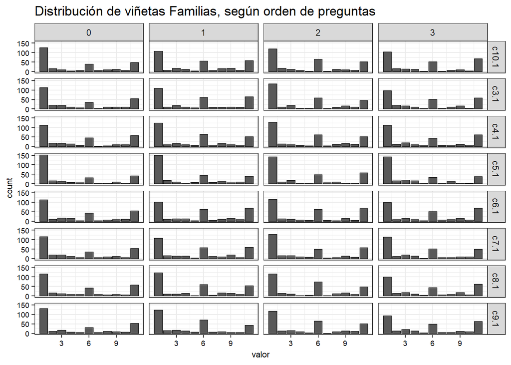

```r
epsoc %>%
  select(i.1.orden, matches('c([3-9]|10).1$')) %>%
  gg_ideologia_orden(i.1.orden) +
  labs(title = 'Distribución de viñetas Familias, según orden de preguntas')
```

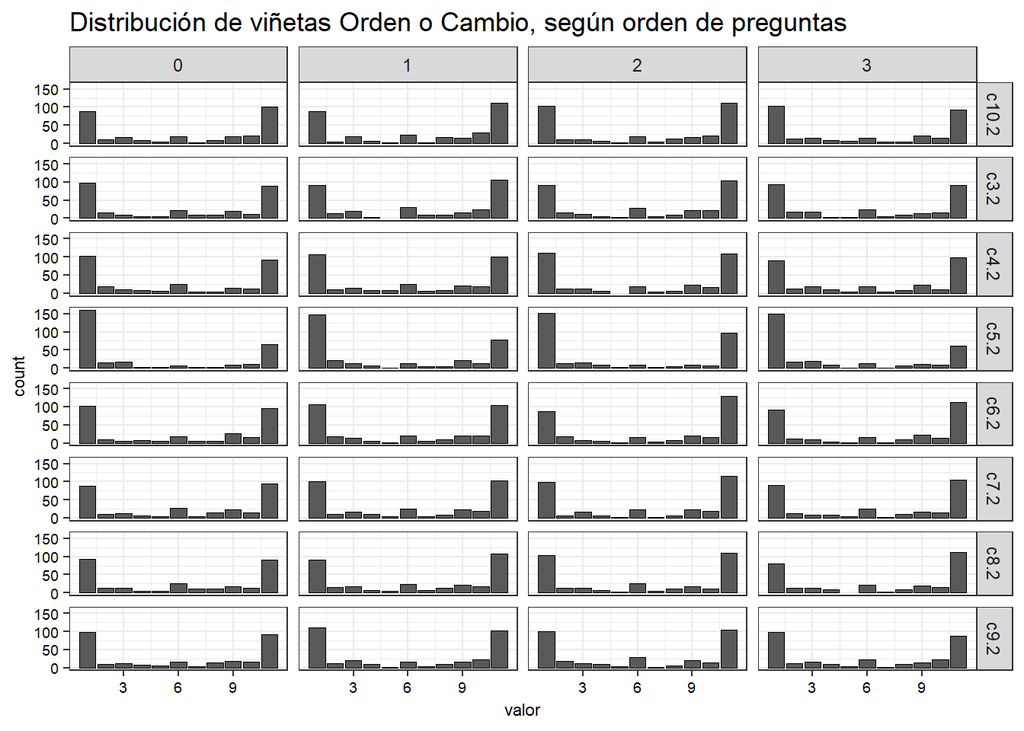

```r
epsoc %>%
  select(i.1.orden, matches('c([3-9]|10).2$')) %>%
  gg_ideologia_orden(i.1.orden) +
  labs(title = 'Distribución de viñetas Orden o Cambio, según orden de preguntas')
```

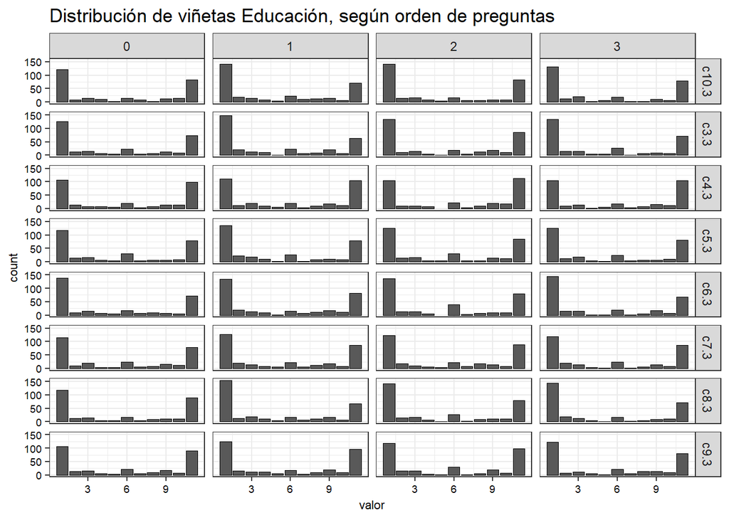

```r
epsoc %>%
  select(i.1.orden, matches('c([3-9]|10).3$')) %>%
  gg_ideologia_orden(i.1.orden) +
  labs(title = 'Distribución de viñetas Educación, según orden de preguntas')
```

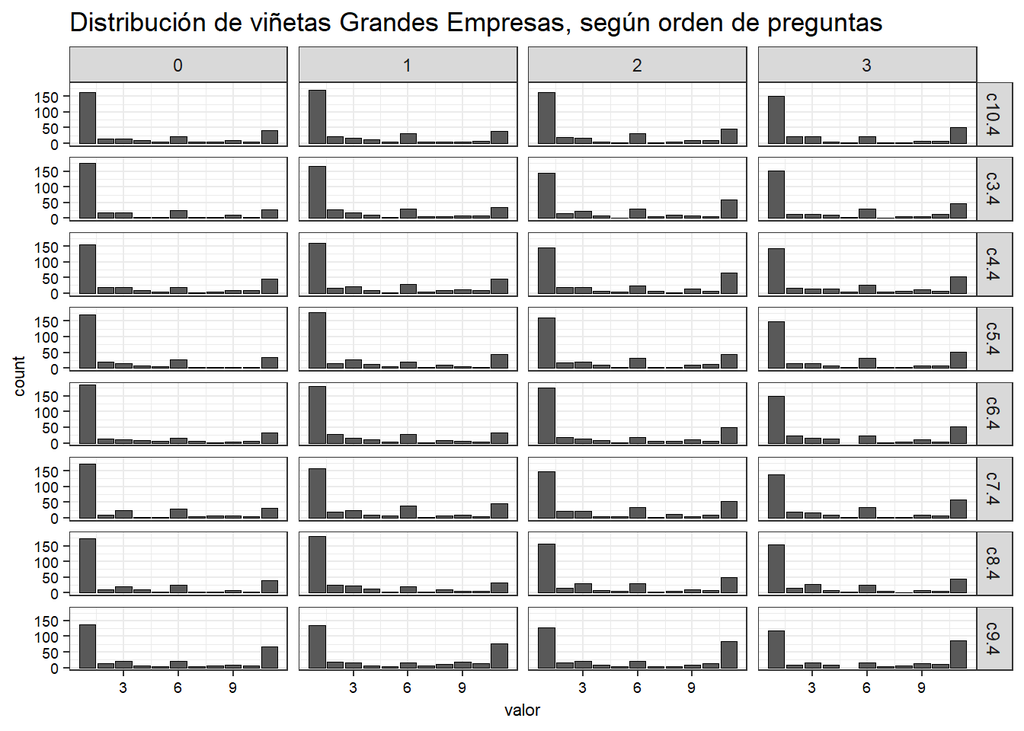

```r
epsoc %>%
  select(i.1.orden, matches('c([3-9]|10).4$')) %>%
  gg_ideologia_orden(i.1.orden) +
  labs(title = 'Distribución de viñetas Grandes Empresas, según orden de preguntas')
```

## 4.2 Recompensa justa

Para validar el experimento de evaluación de justicia necesitamos: - Una breve explicación de cómo están codificados los items de recompensa percibida y recompensa justa para un obrero, el presidente de una empresa y el respondente - Es fundamental saber cuál es la variable que define el orden en que se presentó una y otra pregunta

### 4.2.1 Distribución de tratamientos

La variable a que determina el tratamiento mostrado en la encuesta es la variable `num.grupo.jd`.

```r
flat_table(epsoc, num.grupo.jd, region, margin = 'col')
```

```
##              region     2     9    13
## num.grupo.jd
## 0                   26.39 21.10 22.98
## 1                   24.17 25.00 25.96
## 2                   28.06 25.97 25.26
## 3                   21.39 27.92 25.79
```

### 4.2.2 Variables asociadas

Existen 24 variables asociadas al experimiento de *recompensa justa* que se detallan a continuación:

```r
var_rec_justa <- find_var(epsoc, pattern = stringr::regex('obrero|pdte'), search = 'label')

var_rec_justa$var.label %>%
  str_replace_all(c('Quisiéramos saber cuánto dinero cree Ud. que ganan las personas al mes en estos trabajos u ocupaciones que se mencionan más adelante, después de considerar los descuentos de salud, previsión u otros impuestos' = 'cuánto dinero cree Ud. que ganan',
                    'Pensando en lo que Ud. cree que las personas en estos trabajos deberían ganar al mes, después de los descuentos de salud, previsión u otros impuestos. ' = '')) %>%
   paste0(var_rec_justa$var.name, " - ", sort(rep(seq(6), 4)), " - ", .)
```

```
##  [1] "i.1.g1a.1.rec - 1 - cuánto dinero cree Ud. que ganan (pdte empresa)"
##  [2] "i.2.g1a.1.rec - 1 - cuánto dinero cree Ud. que ganan (obrero)"
##  [3] "i.1.g2a.1.rec - 1 - ¿Cuál sería una remuneración justa para (pdte empresa)?"
##  [4] "i.2.g2a.1.rec - 1 - ¿Cuál sería una remuneración justa para (obrero)?"
##  [5] "i.1.g2a.2.rec - 2 - ¿Cuál sería una remuneración justa para (pdte empresa)?"
##  [6] "i.2.g2a.2.rec - 2 - ¿Cuál sería una remuneración justa para (obrero)?"
##  [7] "i.1.g1a.2.rec - 2 - cuánto dinero cree Ud. que ganan (pdte empresa)"
##  [8] "i.2.g1a.2.rec - 2 - cuánto dinero cree Ud. que ganan (obrero)"
##  [9] "i.1.g1a.3.rec - 3 - cuánto dinero cree Ud. que ganan (pdte empresa)"
## [10] "i.2.g1a.3.rec - 3 - cuánto dinero cree Ud. que ganan (obrero)"
## [11] "i.1.g2b.3.rec - 3 - ¿Cuál sería una remuneración justa para (pdte empresa)?"
## [12] "i.2.g2b.3.rec - 3 - ¿Cuál sería una remuneración justa para (obrero)?"
## [13] "i.1.g1b.4.rec - 4 - ¿Cuál sería una remuneración justa para (pdte empresa)?"
## [14] "i.2.g1b.4.rec - 4 - ¿Cuál sería una remuneración justa para (obrero)?"
## [15] "i.1.g1a.4.rec - 4 - cuánto dinero cree Ud. que ganan (pdte empresa)"
## [16] "i.2.g1a.4.rec - 4 - cuánto dinero cree Ud. que ganan (obrero)"
## [17] "i.1.g1a.3.2.rec - 5 - cuánto dinero cree Ud. que ganan (obrero)"
## [18] "i.2.g1a.3.2.rec - 5 - cuánto dinero cree Ud. que ganan (pdte empresa)"
## [19] "i.1.g1b.3.2.rec - 5 - ¿Cuál sería una remuneración justa para (obrero)?"
## [20] "i.2.g1b.3.2.rec - 5 - ¿Cuál sería una remuneración justa para (pdte empresa)?"
## [21] "i.1.g2b.4.2.rec - 6 - ¿Cuál sería una remuneración justa para (obrero)?"
## [22] "i.2.g2b.4.2.rec - 6 - ¿Cuál sería una remuneración justa para (pdte empresa)?"
## [23] "i.1.g2a.4.2.rec - 6 - cuánto dinero cree Ud. que ganan (obrero)"
## [24] "i.2.g2a.4.2.rec - 6 - cuánto dinero cree Ud. que ganan (pdte empresa)"
```

Al inicio de la aplicación del cuestionario se implementó 4 grupos (del grupo 1 al 4 o variables `i.1.g1a.1.rec` a `i.2.g1a.4.rec`). Como puede verse el grupo 3 es identico al 1 y el grupo 4 es igual al 2 porque se mantuvo el orden de *presidente empresa* y luego *obrero*.

Para solucionarlo, se agregaron los grupos 5 y 6 en donde se se cambia el orden a *obrero* y luego *presidente empresa*. Con esto los 4 grupos (1, 2, 5 y 6) a los que cada persona se verá confrontada serán diferentes. Como se puede ver en el gráfico , la implementación del cambio se efectuó correctamente.

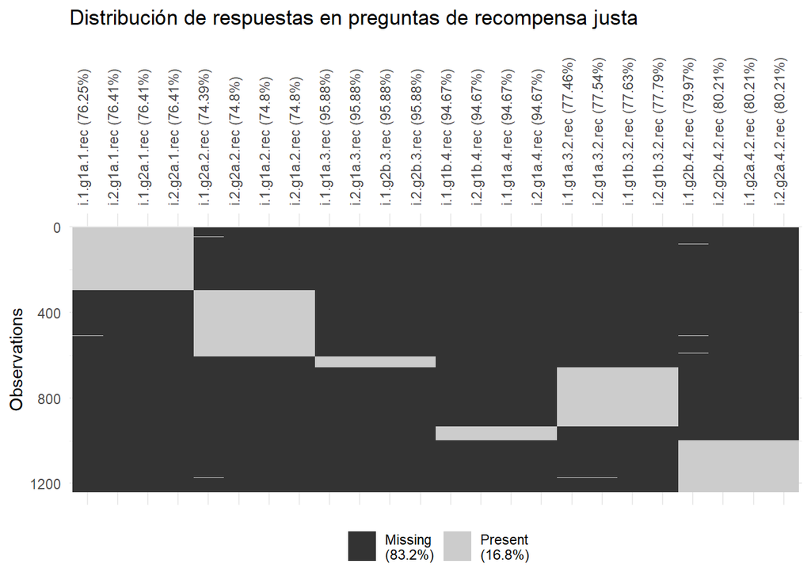

```r
epsoc %>%
  arrange(num.grupo.jd, time1) %>%
  select(one_of(var_rec_justa$var.name)) %>%
  naniar::vis_miss() +
  labs(title = 'Distribución de respuestas en preguntas de recompensa justa') +
  theme(axis.text.x = element_text(angle = 90, vjust = .5, hjust = 0))
```

## 4.3 Items justicia

La encuesta considera una serie de preguntas con escalas predefinidas. A continuación se revisa que los ítems sobre justicia tengan respuestas en el rango de 1 a 5 o bien valores de 8 o 9.

```r
item_just <- find_var(epsoc, "usto")
item_just$var.name
```

```
##  [1] "i.6.a1"  "i.8.a1"  "i.9.a1"  "i.10.a1" "i.11.a1" "i.12.a1" "i.13.a1"
##  [8] "i.16.a1" "i.1.h1"  "i.2.h1"  "i.5.h1"  "i.7.h1"  "i.8.h1"  "i.10.h1"
## [15] "i.11.h1" "i.12.h1" "i.14.h1"
```

```r
v <- validator(j := var_group(i.6.a1, i.8.a1, i.9.a1, i.10.a1, i.11.a1, i.12.a1, i.13.a1, i.16.a1,
                              i.1.h1, i.2.h1, i.5.h1, i.7.h1, i.8.h1, i.10.h1, i.11.h1, i.12.h1, i.14.h1),
               j >= 1,
               j <= 9,
               j != 6,
               j != 7)

cf2 <- confront(epsoc, v)
s.cf2 <- summary(cf2)

knitr::kable(s.cf2) %>%
  kable_estilo()
```

| name | items | passes | fails | nNA | error | warning | expression |
| --- | --- | --- | --- | --- | --- | --- | --- |
| V2.1 | 1238 | 1238 | 0 | 0 | FALSE | FALSE | (i.6.a1 - 1) >= -1e-08 |
| V2.2 | 1238 | 1238 | 0 | 0 | FALSE | FALSE | (i.8.a1 - 1) >= -1e-08 |
| V2.3 | 1238 | 1238 | 0 | 0 | FALSE | FALSE | (i.9.a1 - 1) >= -1e-08 |
| V2.4 | 1238 | 1238 | 0 | 0 | FALSE | FALSE | (i.10.a1 - 1) >= -1e-08 |
| V2.5 | 1238 | 1238 | 0 | 0 | FALSE | FALSE | (i.11.a1 - 1) >= -1e-08 |
| V2.6 | 1238 | 1238 | 0 | 0 | FALSE | FALSE | (i.12.a1 - 1) >= -1e-08 |
| V2.7 | 1238 | 1238 | 0 | 0 | FALSE | FALSE | (i.13.a1 - 1) >= -1e-08 |
| V2.8 | 1238 | 1238 | 0 | 0 | FALSE | FALSE | (i.16.a1 - 1) >= -1e-08 |
| V2.9 | 1238 | 1238 | 0 | 0 | FALSE | FALSE | (i.1.h1 - 1) >= -1e-08 |
| V2.10 | 1238 | 1238 | 0 | 0 | FALSE | FALSE | (i.2.h1 - 1) >= -1e-08 |
| V2.11 | 1238 | 1238 | 0 | 0 | FALSE | FALSE | (i.5.h1 - 1) >= -1e-08 |
| V2.12 | 1238 | 1238 | 0 | 0 | FALSE | FALSE | (i.7.h1 - 1) >= -1e-08 |
| V2.13 | 1238 | 1238 | 0 | 0 | FALSE | FALSE | (i.8.h1 - 1) >= -1e-08 |
| V2.14 | 1238 | 1238 | 0 | 0 | FALSE | FALSE | (i.10.h1 - 1) >= -1e-08 |
| V2.15 | 1238 | 1238 | 0 | 0 | FALSE | FALSE | (i.11.h1 - 1) >= -1e-08 |
| V2.16 | 1238 | 1238 | 0 | 0 | FALSE | FALSE | (i.12.h1 - 1) >= -1e-08 |
| V2.17 | 1238 | 1238 | 0 | 0 | FALSE | FALSE | (i.14.h1 - 1) >= -1e-08 |
| V3.1 | 1238 | 1238 | 0 | 0 | FALSE | FALSE | (i.6.a1 - 9) <= 1e-08 |
| V3.2 | 1238 | 1238 | 0 | 0 | FALSE | FALSE | (i.8.a1 - 9) <= 1e-08 |
| V3.3 | 1238 | 1238 | 0 | 0 | FALSE | FALSE | (i.9.a1 - 9) <= 1e-08 |
| V3.4 | 1238 | 1238 | 0 | 0 | FALSE | FALSE | (i.10.a1 - 9) <= 1e-08 |
| V3.5 | 1238 | 1238 | 0 | 0 | FALSE | FALSE | (i.11.a1 - 9) <= 1e-08 |
| V3.6 | 1238 | 1238 | 0 | 0 | FALSE | FALSE | (i.12.a1 - 9) <= 1e-08 |
| V3.7 | 1238 | 1238 | 0 | 0 | FALSE | FALSE | (i.13.a1 - 9) <= 1e-08 |
| V3.8 | 1238 | 1238 | 0 | 0 | FALSE | FALSE | (i.16.a1 - 9) <= 1e-08 |
| V3.9 | 1238 | 1238 | 0 | 0 | FALSE | FALSE | (i.1.h1 - 9) <= 1e-08 |
| V3.10 | 1238 | 1238 | 0 | 0 | FALSE | FALSE | (i.2.h1 - 9) <= 1e-08 |
| V3.11 | 1238 | 1238 | 0 | 0 | FALSE | FALSE | (i.5.h1 - 9) <= 1e-08 |
| V3.12 | 1238 | 1238 | 0 | 0 | FALSE | FALSE | (i.7.h1 - 9) <= 1e-08 |
| V3.13 | 1238 | 1238 | 0 | 0 | FALSE | FALSE | (i.8.h1 - 9) <= 1e-08 |
| V3.14 | 1238 | 1238 | 0 | 0 | FALSE | FALSE | (i.10.h1 - 9) <= 1e-08 |
| V3.15 | 1238 | 1238 | 0 | 0 | FALSE | FALSE | (i.11.h1 - 9) <= 1e-08 |
| V3.16 | 1238 | 1238 | 0 | 0 | FALSE | FALSE | (i.12.h1 - 9) <= 1e-08 |
| V3.17 | 1238 | 1238 | 0 | 0 | FALSE | FALSE | (i.14.h1 - 9) <= 1e-08 |
| V4.1 | 1238 | 1238 | 0 | 0 | FALSE | FALSE | i.6.a1 != 6 |
| V4.2 | 1238 | 1238 | 0 | 0 | FALSE | FALSE | i.8.a1 != 6 |
| V4.3 | 1238 | 1238 | 0 | 0 | FALSE | FALSE | i.9.a1 != 6 |
| V4.4 | 1238 | 1238 | 0 | 0 | FALSE | FALSE | i.10.a1 != 6 |
| V4.5 | 1238 | 1238 | 0 | 0 | FALSE | FALSE | i.11.a1 != 6 |
| V4.6 | 1238 | 1238 | 0 | 0 | FALSE | FALSE | i.12.a1 != 6 |
| V4.7 | 1238 | 1238 | 0 | 0 | FALSE | FALSE | i.13.a1 != 6 |
| V4.8 | 1238 | 1238 | 0 | 0 | FALSE | FALSE | i.16.a1 != 6 |
| V4.9 | 1238 | 1238 | 0 | 0 | FALSE | FALSE | i.1.h1 != 6 |
| V4.10 | 1238 | 1238 | 0 | 0 | FALSE | FALSE | i.2.h1 != 6 |
| V4.11 | 1238 | 1238 | 0 | 0 | FALSE | FALSE | i.5.h1 != 6 |
| V4.12 | 1238 | 1238 | 0 | 0 | FALSE | FALSE | i.7.h1 != 6 |
| V4.13 | 1238 | 1238 | 0 | 0 | FALSE | FALSE | i.8.h1 != 6 |
| V4.14 | 1238 | 1238 | 0 | 0 | FALSE | FALSE | i.10.h1 != 6 |
| V4.15 | 1238 | 1238 | 0 | 0 | FALSE | FALSE | i.11.h1 != 6 |
| V4.16 | 1238 | 1238 | 0 | 0 | FALSE | FALSE | i.12.h1 != 6 |
| V4.17 | 1238 | 1238 | 0 | 0 | FALSE | FALSE | i.14.h1 != 6 |
| V5.1 | 1238 | 1238 | 0 | 0 | FALSE | FALSE | i.6.a1 != 7 |
| V5.2 | 1238 | 1238 | 0 | 0 | FALSE | FALSE | i.8.a1 != 7 |
| V5.3 | 1238 | 1238 | 0 | 0 | FALSE | FALSE | i.9.a1 != 7 |
| V5.4 | 1238 | 1238 | 0 | 0 | FALSE | FALSE | i.10.a1 != 7 |
| V5.5 | 1238 | 1238 | 0 | 0 | FALSE | FALSE | i.11.a1 != 7 |
| V5.6 | 1238 | 1238 | 0 | 0 | FALSE | FALSE | i.12.a1 != 7 |
| V5.7 | 1238 | 1238 | 0 | 0 | FALSE | FALSE | i.13.a1 != 7 |
| V5.8 | 1238 | 1238 | 0 | 0 | FALSE | FALSE | i.16.a1 != 7 |
| V5.9 | 1238 | 1238 | 0 | 0 | FALSE | FALSE | i.1.h1 != 7 |
| V5.10 | 1238 | 1238 | 0 | 0 | FALSE | FALSE | i.2.h1 != 7 |
| V5.11 | 1238 | 1238 | 0 | 0 | FALSE | FALSE | i.5.h1 != 7 |
| V5.12 | 1238 | 1238 | 0 | 0 | FALSE | FALSE | i.7.h1 != 7 |
| V5.13 | 1238 | 1238 | 0 | 0 | FALSE | FALSE | i.8.h1 != 7 |
| V5.14 | 1238 | 1238 | 0 | 0 | FALSE | FALSE | i.10.h1 != 7 |
| V5.15 | 1238 | 1238 | 0 | 0 | FALSE | FALSE | i.11.h1 != 7 |
| V5.16 | 1238 | 1238 | 0 | 0 | FALSE | FALSE | i.12.h1 != 7 |
| V5.17 | 1238 | 1238 | 0 | 0 | FALSE | FALSE | i.14.h1 != 7 |

Existen 0 variables de actitudes sobre justicia fuera de rango.

# 5 Otros criterios generales

Para validar los datos consideramos los siguientes criterios:

- El rango etario de la población (18 a 59 años)
- Una duración de menos de dos horas
- Una duración de más de quince minutos
- Las variables con información redundante deben converger (edad y sexo)

```r
epsoc$duration <- chron(times=epsoc$duration)
cf <- check_that(epsoc, edad.seleccionado <= 59 & edad.seleccionado >= 18,
                 sexo.enc == sexo.seleccionado)
s.cf <- summary(cf)
knitr::kable(s.cf) %>%
        kable_estilo()
```

| name | items | passes | fails | nNA | error | warning | expression |
| --- | --- | --- | --- | --- | --- | --- | --- |
| V1 | 1238 | 1237 | 1 | 0 | FALSE | FALSE | edad.seleccionado <= 59 & edad.seleccionado >= 18 |
| V2 | 1238 | 1238 | 0 | 0 | FALSE | FALSE | abs(sexo.enc - sexo.seleccionado) < 1e-08 |

Resultados:

- Existen 1 respondentes fuera del rango etario.
- No existen divergencias respecto al sexo del encuestado al comparar la variable `sexo.enc` y `sexo.seleccionado`.

```r
## Fecha de nacimiento y edad seleccionado
epsoc$enc.edad[as.character(epsoc$enc.edad) == "1582-10-14"] <- NA # comportamiento extraño al importar desde SPSS
edad <- tibble(Folio = epsoc$folio[is.na(epsoc$enc.edad)],
               Fecha = epsoc$enc.edad[is.na(epsoc$enc.edad)],
               Edad = epsoc$edad.seleccionado[is.na(epsoc$enc.edad)])
knitr::kable(edad,
             caption = "Casos sin fecha de nacimiento en `enc_edad`",
             col.names = c("Folio", "Fecha nacimiento", "Edad")) %>%
  kable_estilo()
```

Casos sin fecha de nacimiento en `enc_edad`

| Folio | Fecha nacimiento | Edad |
| --- | --- | --- |
| 201350 | NA | 56 |
| 201467 | NA | 59 |
| 202457 | NA | 18 |
| 202580 | NA | 59 |
| 203182 | NA | 39 |
| 203273 | NA | 59 |
| 203315 | NA | 52 |
| 205237 | NA | 59 |
| 900134 | NA | 59 |
| 900753 | NA | 53 |
| 900779 | NA | 59 |
| 900829 | NA | 40 |
| 900845 | NA | 59 |
| 900878 | NA | 59 |
| 901041 | NA | 59 |
| 901066 | NA | 59 |
| 901082 | NA | 39 |
| 901579 | NA | 40 |
| 901918 | NA | 25 |
| 902338 | NA | 56 |
| 902361 | NA | 59 |
| 902379 | NA | 59 |
| 902510 | NA | 59 |
| 902924 | NA | 59 |
| 903336 | NA | 59 |
| 903351 | NA | 59 |
| 903419 | NA | 59 |
| 903518 | NA | 59 |
| 903526 | NA | 59 |
| 903567 | NA | 59 |
| 903955 | NA | 59 |
| 904144 | NA | 56 |
| 904383 | NA | 53 |
| 904565 | NA | 43 |
| 904722 | NA | 59 |
| 904771 | NA | 59 |
| 905224 | NA | 59 |
| 905273 | NA | 59 |
| 905299 | NA | 59 |
| 905364 | NA | 59 |
| 905422 | NA | 59 |
| 905448 | NA | 59 |
| 905471 | NA | 51 |
| 905877 | NA | 20 |
| 905976 | NA | 59 |
| 1302538 | NA | 47 |
| 1303270 | NA | 34 |
| 1303577 | NA | 39 |
| 1309913 | NA | 49 |
| 1310150 | NA | 55 |
| 1310168 | NA | 27 |
| 1310176 | NA | 52 |
| 1310192 | NA | 35 |
| 1311935 | NA | 24 |
| 1312438 | NA | 48 |

```r
epsoc %>%
  filter(sexo.enc != sexo.seleccionado) %>%
  select(Folio = folio, sexo.enc, sexo.seleccionado) %>%
  knitr::kable(col.names = c("Folio", "sexo.enc", "sexo.seleccionado"),
               caption = "Entrevistas donde sexo encuestado y seleccionado no coinciden") %>%
  kable_estilo()
```

Entrevistas donde sexo encuestado y seleccionado no coinciden

| Folio | sexo.enc | sexo.seleccionado |
| --- | --- | --- |

# 6 Grabaciones

Grabar base de datos con variables de viñetas reconstruidas.

```r
epsoc %>%
  mutate_if(is.numeric, as_labelled) %>%
  haven::write_sav("../EPSOC Base parcial con vinetas.sav")
```

Obtención de archivos de grabaciones de cada encuesta.

```r
 path_general <- '../SurveyToGo Attachments/EPSOC 2018/'

 archivos <- dir(path = path_general,
     pattern = str_c(epsoc$sbj.num, collapse = '|'),
     recursive = TRUE)

 file.copy(from = str_c(path_general, archivos),
           to = "grabaciones/",
           overwrite = TRUE)
```